# 140.651 - Lab 13

### HW6 Problem 1

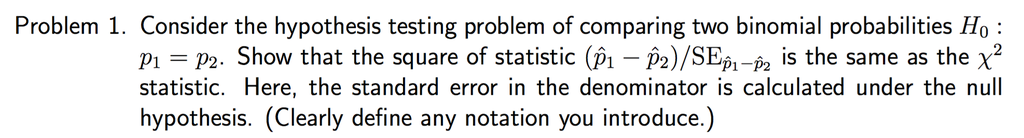

Consider 2x2 table:

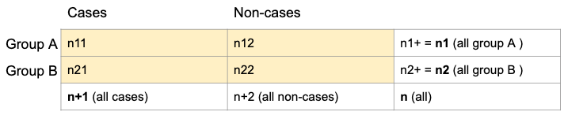

##### 2x2 table notation explained

Table entries:

- $n_{11}$ - number of patients in treatment group $A$ who are cases;
- $n_{12}$ - number of patients in treatment group $A$ who are not cases;
- $n_{21}$ - number of patients in treatment group $B$ who are cases;
- $n_{22}$ - number of patients in treatment group $B$ who are not cases.

Column sums:

- $n_{+1}$ - number of cases,
- $n_{+2}$ - number of controls.

Row sums:

- $n_{1+} = n_1$ - number of patients in treatment group $A$;
- $n_{2+} = n_2$ - number of patients in treatment group $B$;

Total sum:

- $n$ - all participants.

##### 2x2 table notation to z-test of proportion differences notation

Proportion of cases among patients in treatment $A$:

- $\hat{p}_1=n_{11}/n_1$

Proportion of cases among patients in treatment $B$:

- $\hat{p}_2=n_{21}/n_2$

Pooled estimate of proportion of cases (all cases to all individuals)

- $\hat{p}=(n_{11}+n_{21})/(n_{1}+n_{2}) = (\hat{p}_1 n_1 +\hat{p}_2 n_2)/(n_{1}+n_{2})$

Finally, **the square of Z statistic**, assuming pooled estimate of proportion of cases, is (lecture 18 slide 12)
$$\Big(\frac{\hat{p}_1-\hat{p}_2}{SE_{\hat{p}_1-\hat{p}_2}}\Big)^2=\frac{(\hat{p}_1-\hat{p}_2)^2}{\hat{p}(1-\hat{p})\big(\frac{1}{n_1}+\frac{1}{n_2}\big)}.$$
.

##### 2x2 table notation to Pearson’s $\chi^2$ test

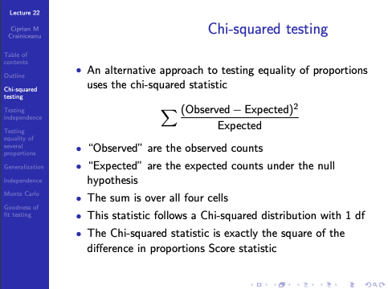

Pearson’s $\chi^2$ test $H_0$: There is no relationship between the two variables (here: case/non-case status, treatment group).

- Compare with z-test $H_0$: There is no statistical difference between the means (here: proportion of case/non-case status) of the two groups (here: treatment group).

Example for a cell of number of patients in treatment group $A$ who are cases (upper-left cell):

- Observed: $n_{11} = n_1 \hat{p}_1$
- Expected under null hypothesis: $n_1 \hat{p}$

##### Derivation

We will show equivalence of

- The squre of the $Z$ statistic is (lecture 18 slide 12)
  $$\Big(\frac{\hat{p}_1-\hat{p}_2}{SE_{\hat{p}_1-\hat{p}_2}}\Big)^2=\frac{(\hat{p}_1-\hat{p}_2)^2}{\hat{p}(1-\hat{p})\big(\frac{1}{n_1}+\frac{1}{n_2}\big)},$$
  where $\hat{p}=\frac{n_1\hat{p}_1+n_2\hat{p}_2}{n_1+n_2}$.

The $\chi^2$ statistic can be rewritten as
$$\begin{align*}
\chi^2&=\frac{(n_1\hat{p}_1-n_1\hat{p})^2}{n_1\hat{p}}+\frac{(n_1(1-\hat{p}_1)-n_1(1-\hat{p}))^2}{n_1(1-\hat{p})}+\frac{(n_2\hat{p}_2-n_2\hat{p})^2}{n_2\hat{p}}+\frac{(n_2(1-\hat{p}_2)-n_2(1-\hat{p}))^2}{n_2(1-\hat{p})} \\
&= \frac{n_1(\hat{p}_1-\hat{p})^2}{\hat{p}}+\frac{n_1(\hat{p}_1-\hat{p})^2}{1-\hat{p}}+\frac{n_2(\hat{p}_2-\hat{p})^2}{\hat{p}}+\frac{n_2(\hat{p}_2-\hat{p})^2}{1-\hat{p}}\\
&= \frac{n_1(\hat{p}_1-\hat{p})^2+n_2(\hat{p}_2-\hat{p})^2}{\hat{p}(1-\hat{p})} \\
& =\frac{n_1\hat{p}_1^2+n_2\hat{p}_2^2-2(n_1\hat{p}_1+n_2\hat{p}_2)\hat{p}+(n_1+n_2)\hat{p}^2}{\hat{p}(1-\hat{p})}\\ &=\frac{n_1\hat{p}_1^2+n_2\hat{p}_2^2-(n_1+n_2)\hat{p}^2}{\hat{p}(1-\hat{p})}\\
&= \frac{n_1\hat{p}_1^2+n_2\hat{p}_2^2-(n_1\hat{p}_1+n_2\hat{p}_2)^2/(n_1+n_2)}{\hat{p}(1-\hat{p})}\\
&= \frac{\frac{n_1n_2}{n_1+n_2}(\hat{p}_1-\hat{p}_2)^2}{\hat{p}(1-\hat{p})} = \Big(\frac{\hat{p}_1-\hat{p}_2}{SE_{\hat{p}_1-\hat{p}_2}}\Big)^2
\end{align*}$$

Where:

- Line 1: write out sum of $\frac{(observed-expected)^2}{expected}$ over 4 cells of 2x2 table,
- Line 2: take out $n_1$ or $n_2$ outside brackets with square, cancel with numerator,
- Line 3: algebra; put all 4 elements to common denominator, sum and organize numerator
- Lines 4-5: algebra
- Line 6: use definition of $\hat{p}=\frac{n_1\hat{p}_1+n_2\hat{p}_2}{n_1+n_2}$.